# Linear regression

Exercises for chapter three of An Introduction to Statistical Learning.

```r
library(MASS)
library(ISLR)
```

## Pregunta 8

8. This question involves the use of simple linear regression on the *Auto* data set.
1. Use the *lm()* function to perform a simple linear regression with *mpg* as the  
   response and *horsepower* as the predictor. Use the *summary()* function to print the r esults. Comment on the output.

```r
q8.a = lm(mpg~horsepower, data = Auto)
summary(q8.a)
```

```
Call:
lm(formula = mpg ~ horsepower, data = Auto)

Residuals:
     Min       1Q   Median       3Q      Max
-13.5710  -3.2592  -0.3435   2.7630  16.9240

Coefficients:
             Estimate Std. Error t value Pr(>|t|)
(Intercept) 39.935861   0.717499   55.66   <2e-16 ***
horsepower  -0.157845   0.006446  -24.49   <2e-16 ***
---
Signif. codes:  0 ‘***’ 0.001 ‘**’ 0.01 ‘*’ 0.05 ‘.’ 0.1 ‘ ’ 1

Residual standard error: 4.906 on 390 degrees of freedom
Multiple R-squared:  0.6059,    Adjusted R-squared:  0.6049
F-statistic: 599.7 on 1 and 390 DF,  p-value: < 2.2e-16
```

```r
predict(q8.a, data.frame(horsepower=c(98)), interval = "confidence")
```

```
       fit      lwr      upr
1 24.46708 23.97308 24.96108
```

Observemos que el bajo valor p da evidencia fuerte de una relación entre el predictor y la respuesta. El valor de R^2 indica que podemos explicar 60% de la variación en las millas por galón por los caballos de fuerza; y la pendiente negativa indica que mientras menos caballos de fuerza tenga el auto, más rinde. Para poner ejemplos numéricos, con 98 caballos de fuerza el coche rendiría 24.47 millas por galón según la estimación. Los intervalos de confianza indican que con 95% de probabilidades, el valor real está entre 23.973 y 24.961 millas por galón.

2. Grafique la respuesta y el predictor, usando *abline()* para mostrar también la recta de mínimos cuadrados.

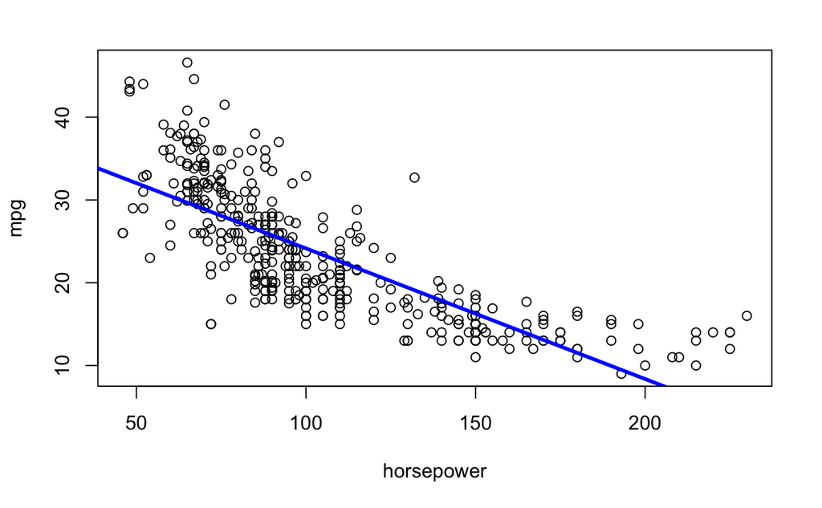

```r
with(Auto, plot(horsepower, mpg))
abline(q8.a, lw = 3, col="blue")
```

3. Use *plot()* para producir gráficas diagnósticas de la regresión por mínimos cuadrados. Comente.

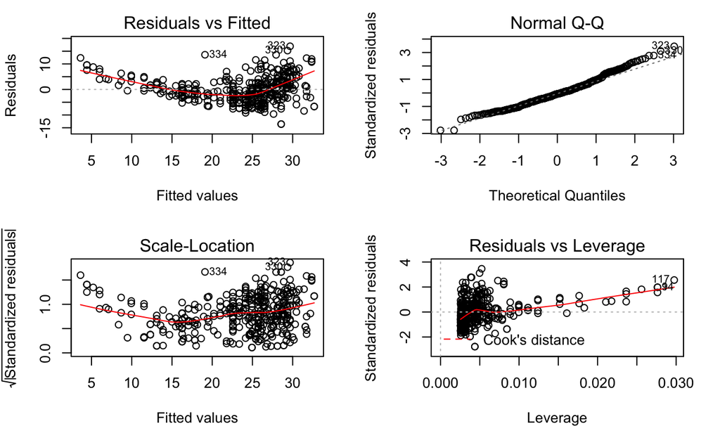

```r
par(mfrow = c(2,2))
plot(q8.a)
```

La gráfica de residuos contra valores muestra un patrón claro, sugiriendo no-linealidad en los datos. La gráfica de residusos estandarizados parece corroborar el supuesto de heterocedasticidad. La observación 334 tiene un valor muy alto en la gráfica de residuos estandarizados.

## Pregunta 9

This question involves the use of multiple linear regression on the *Auto* data set.

1. Produce a scatterplot matrix which includes all of the variables in the data set

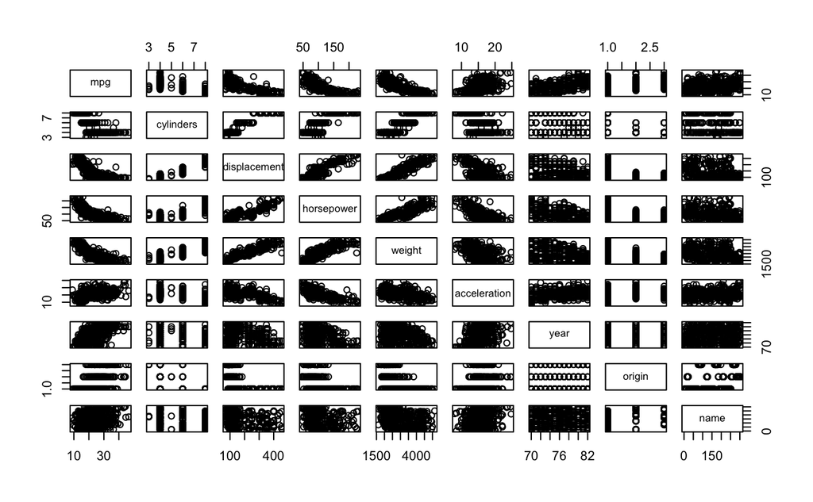

```r
pairs(Auto)
```

2. Compute the matrix of correlations between the variables using the function *cor()*. You will need to exclude the *name* variable, which is qualitative.

```r
cor(Auto[sapply(Auto, function(x) is.numeric(x))])
```

```
                    mpg  cylinders displacement horsepower     weight acceleration
mpg           1.0000000 -0.7776175   -0.8051269 -0.7784268 -0.8322442    0.4233285
cylinders    -0.7776175  1.0000000    0.9508233  0.8429834  0.8975273   -0.5046834
displacement -0.8051269  0.9508233    1.0000000  0.8972570  0.9329944   -0.5438005
horsepower   -0.7784268  0.8429834    0.8972570  1.0000000  0.8645377   -0.6891955
weight       -0.8322442  0.8975273    0.9329944  0.8645377  1.0000000   -0.4168392
acceleration  0.4233285 -0.5046834   -0.5438005 -0.6891955 -0.4168392    1.0000000
year          0.5805410 -0.3456474   -0.3698552 -0.4163615 -0.3091199    0.2903161
origin        0.5652088 -0.5689316   -0.6145351 -0.4551715 -0.5850054    0.2127458
                   year     origin
mpg           0.5805410  0.5652088
cylinders    -0.3456474 -0.5689316
displacement -0.3698552 -0.6145351
horsepower   -0.4163615 -0.4551715
weight       -0.3091199 -0.5850054
acceleration  0.2903161  0.2127458
year          1.0000000  0.1815277
origin        0.1815277  1.0000000
```

3. Use *lm()* to perform a multiple linear regression with *mpg* as the response and all other variables except *name* as predictors. Print a summary and comment.

```r
q9.c = lm(mpg~.-name, data=Auto)
summary(q9.c)
```

```
Call:
lm(formula = mpg ~ . - name, data = Auto)

Residuals:
    Min      1Q  Median      3Q     Max
-9.5903 -2.1565 -0.1169  1.8690 13.0604

Coefficients:
               Estimate Std. Error t value Pr(>|t|)
(Intercept)  -17.218435   4.644294  -3.707  0.00024 ***
cylinders     -0.493376   0.323282  -1.526  0.12780
displacement   0.019896   0.007515   2.647  0.00844 **
horsepower    -0.016951   0.013787  -1.230  0.21963
weight        -0.006474   0.000652  -9.929  < 2e-16 ***
acceleration   0.080576   0.098845   0.815  0.41548
year           0.750773   0.050973  14.729  < 2e-16 ***
origin         1.426141   0.278136   5.127 4.67e-07 ***
---
Signif. codes:  0 ‘***’ 0.001 ‘**’ 0.01 ‘*’ 0.05 ‘.’ 0.1 ‘ ’ 1

Residual standard error: 3.328 on 384 degrees of freedom
Multiple R-squared:  0.8215,    Adjusted R-squared:  0.8182
F-statistic: 252.4 on 7 and 384 DF,  p-value: < 2.2e-16
```

Hay evidencia de que el peso, el año y el lugar de origen del auto tienen una correlación fuerte con las millas por galón que rinde el auto. El coeficiente de año sugiere que los autos modernos son cada vez más eficientes.

4. Produce and comment diagnostic plots for the regression.

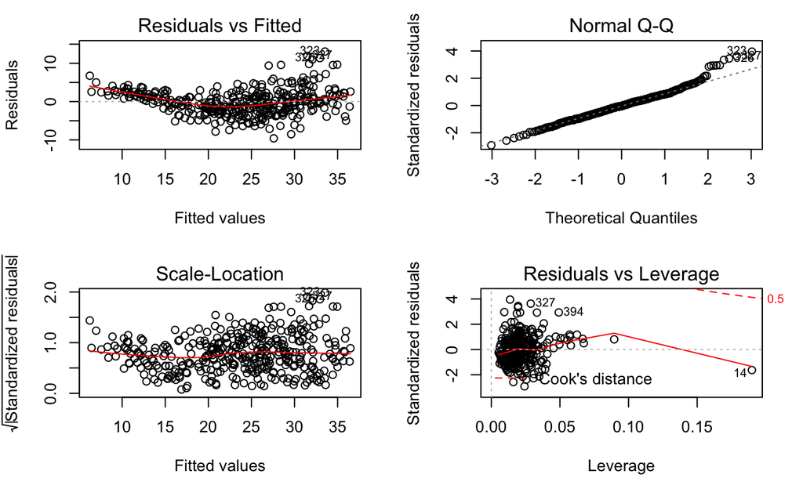

```r
par(mfrow = c(2,2))
plot(q9.c)
```

```r
AutoArreglado = Auto[-14,]
q9.d = lm(mpg~ .-name, data=AutoArreglado)
summary(q9.d)
```

```
Call:
lm(formula = mpg ~ . - name, data = AutoArreglado)

Residuals:
   Min     1Q Median     3Q    Max
-9.551 -2.147 -0.048  1.889 13.056

Coefficients:
               Estimate Std. Error t value Pr(>|t|)
(Intercept)  -1.771e+01  4.644e+00  -3.813  0.00016 ***
cylinders    -5.469e-01  3.242e-01  -1.687  0.09247 .
displacement  2.306e-02  7.745e-03   2.977  0.00309 **
horsepower   -1.105e-02  1.422e-02  -0.777  0.43769
weight       -6.916e-03  7.046e-04  -9.815  < 2e-16 ***
acceleration  1.163e-01  1.010e-01   1.151  0.25043
year          7.551e-01  5.093e-02  14.825  < 2e-16 ***
origin        1.427e+00  2.775e-01   5.142 4.35e-07 ***
---
Signif. codes:  0 ‘***’ 0.001 ‘**’ 0.01 ‘*’ 0.05 ‘.’ 0.1 ‘ ’ 1

Residual standard error: 3.32 on 383 degrees of freedom
Multiple R-squared:  0.822, Adjusted R-squared:  0.8188
F-statistic: 252.7 on 7 and 383 DF,  p-value: < 2.2e-16
```

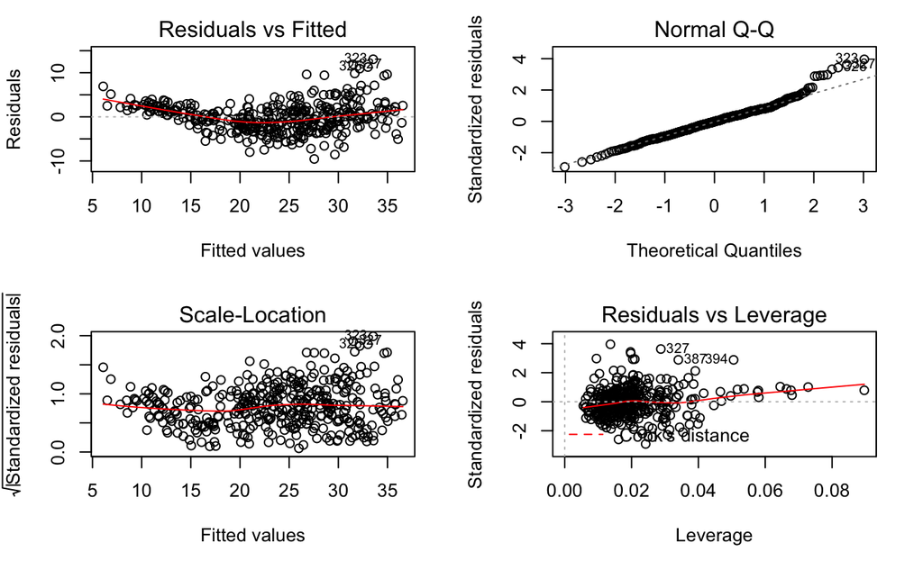

```r
par(mfrow=c(2,2))
plot(q9.d)
```

5. Try regression models with interaction terms using interaction terms. Do any of them appear significant?

```r
q9.e = lm(mpg~.-name+weight:acceleration, data=AutoArreglado)
summary(q9.e)
```

```
Call:
lm(formula = mpg ~ . - name + weight:acceleration, data = AutoArreglado)

Residuals:
    Min      1Q  Median      3Q     Max
-8.2378 -2.0465 -0.0551  1.6288 12.1841

Coefficients:
                      Estimate Std. Error t value Pr(>|t|)
(Intercept)         -4.386e+01  5.878e+00  -7.462 5.80e-13 ***
cylinders           -2.023e-01  3.114e-01  -0.650 0.516219
displacement         2.439e-03  7.954e-03   0.307 0.759257
horsepower          -4.263e-02  1.427e-02  -2.987 0.002994 **
weight               4.218e-03  1.789e-03   2.358 0.018902 *
acceleration         1.641e+00  2.467e-01   6.653 9.97e-11 ***
year                 7.818e-01  4.840e-02  16.152  < 2e-16 ***
origin               1.028e+00  2.695e-01   3.816 0.000158 ***
weight:acceleration -5.892e-04  8.785e-05  -6.707 7.18e-11 ***
---
Signif. codes:  0 ‘***’ 0.001 ‘**’ 0.01 ‘*’ 0.05 ‘.’ 0.1 ‘ ’ 1

Residual standard error: 3.145 on 382 degrees of freedom
Multiple R-squared:  0.8408,    Adjusted R-squared:  0.8375
F-statistic: 252.2 on 8 and 382 DF,  p-value: < 2.2e-16
```

6. Try a few different transformations of the variables. Comment on your findings.

```r
Auto2 = AutoArreglado[-29, ]
q9.f = lm(mpg ~.-name+weight:acceleration-cylinders+cylinders^2-displacement+displacement:displacement, data = Auto2)
summary(q9.f)
```

```
Call:
lm(formula = mpg ~ . - name + weight:acceleration - cylinders +
    cylinders^2 - displacement + displacement:displacement, data = Auto2)

Residuals:
    Min      1Q  Median      3Q     Max
-8.1928 -2.0413 -0.0553  1.5762 12.1914

Coefficients:
                      Estimate Std. Error t value Pr(>|t|)
(Intercept)         -4.424e+01  5.911e+00  -7.484 5.04e-13 ***
horsepower          -4.273e-02  1.428e-02  -2.992 0.002952 **
weight               4.279e-03  1.793e-03   2.386 0.017507 *
acceleration         1.652e+00  2.474e-01   6.676 8.69e-11 ***
year                 7.846e-01  4.863e-02  16.134  < 2e-16 ***
origin               1.015e+00  2.705e-01   3.752 0.000202 ***
cylinders           -2.006e-01  3.116e-01  -0.644 0.520112
displacement         2.375e-03  7.961e-03   0.298 0.765645
weight:acceleration -5.926e-04  8.807e-05  -6.728 6.32e-11 ***
---
Signif. codes:  0 ‘***’ 0.001 ‘**’ 0.01 ‘*’ 0.05 ‘.’ 0.1 ‘ ’ 1

Residual standard error: 3.147 on 381 degrees of freedom
Multiple R-squared:  0.8409,    Adjusted R-squared:  0.8375
F-statistic: 251.7 on 8 and 381 DF,  p-value: < 2.2e-16
```

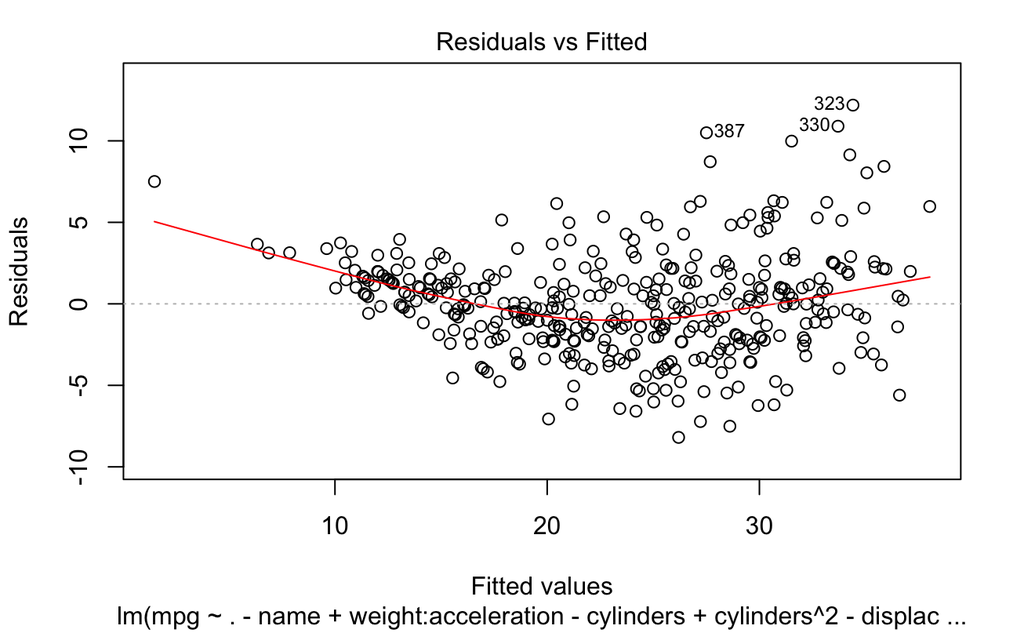

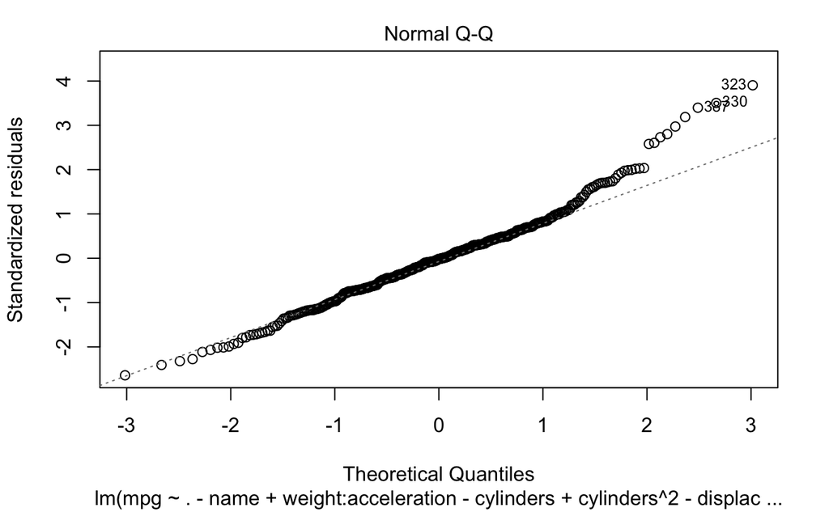

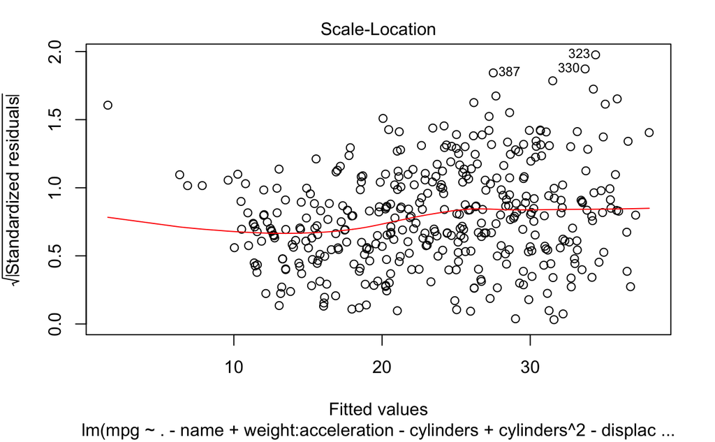

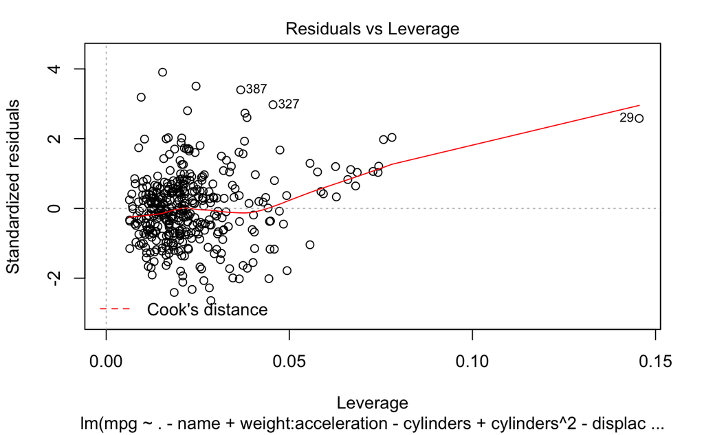

```r
plot(q9.f)
```

# Pregunta 10

This cuestion should be answered using the *Carseats* data set. (a) Find a multiple regression model to predict *Sales* using *Price*, *Urban* and *US*

```r
?Carseats
q10.a = lm(Sales~Price+Urban+US, data=Carseats)
summary(q10.a)
```

```
Call:
lm(formula = Sales ~ Price + Urban + US, data = Carseats)

Residuals:
    Min      1Q  Median      3Q     Max
-6.9206 -1.6220 -0.0564  1.5786  7.0581

Coefficients:
             Estimate Std. Error t value Pr(>|t|)
(Intercept) 13.043469   0.651012  20.036  < 2e-16 ***
Price       -0.054459   0.005242 -10.389  < 2e-16 ***
UrbanYes    -0.021916   0.271650  -0.081    0.936
USYes        1.200573   0.259042   4.635 4.86e-06 ***
---
Signif. codes:  0 ‘***’ 0.001 ‘**’ 0.01 ‘*’ 0.05 ‘.’ 0.1 ‘ ’ 1

Residual standard error: 2.472 on 396 degrees of freedom
Multiple R-squared:  0.2393,    Adjusted R-squared:  0.2335
F-statistic: 41.52 on 3 and 396 DF,  p-value: < 2.2e-16
```

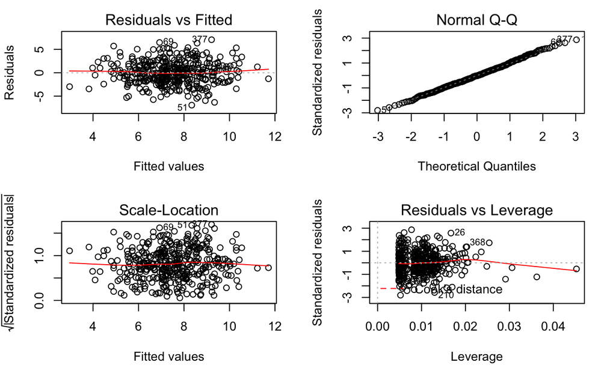

```r
par(mfrow = c(2,2))
plot(q10.a)
```